# Traffic_Sign_Classification

### Group 3 :- Traffic Signal Classification Using CNN

#### ID: 9014533

### Problem

For international travelers, driving in unfamiliar countries can pose significant challenges, particularly when confronted with diverse traffic signals and road signage. Misinterpreting these visual cues can lead to accidents, fines, and even legal repercussions.

### Targeted Resolution

In this project, we will use Convolutional Neural Network to build train and test a traffic sign classification model. We will build this model using tensorflow and keras. It is a multiclass classification problem. This model can be used to make smarter cars.

### Importing required libraries.

```python
# Importing libraries
import os
import pandas as pd
import numpy as np
import matplotlib.pyplot as plt
from matplotlib.image import imread
import seaborn as sns
import random
from PIL import Image
from sklearn.model_selection import  train_test_split
from tensorflow.keras.utils import to_categorical
import tensorflow as tf
from tensorflow.keras.models import Sequential
from tensorflow.keras.layers import Dense, Flatten, Dropout, Conv2D, MaxPool2D
from tensorflow.keras.callbacks import ModelCheckpoint
from tensorflow.keras.regularizers import l2
from tensorflow.keras.callbacks import EarlyStopping
from tensorflow.keras.layers import Conv2D, MaxPooling2D, Flatten, Dense, Dropout
from sklearn.utils.class_weight import compute_class_weight
from sklearn.metrics import classification_report, precision_recall_curve, roc_curve, auc
import matplotlib.pyplot as plt
from sklearn.preprocessing import label_binarize
from sklearn.metrics import roc_auc_score
```

```python
print("Total training images:", sum(len(os.listdir(f'traffic_sign_dataset/Train/{i}')) for i in range(43)), "Total test images:", len(os.listdir('traffic_sign_dataset/Test')))
```

```
Total training images: 39209 Total test images: 12630
```

### Visualizing some images of traffic sign from the test dataset, we can see here that the dimension of images are uneven.

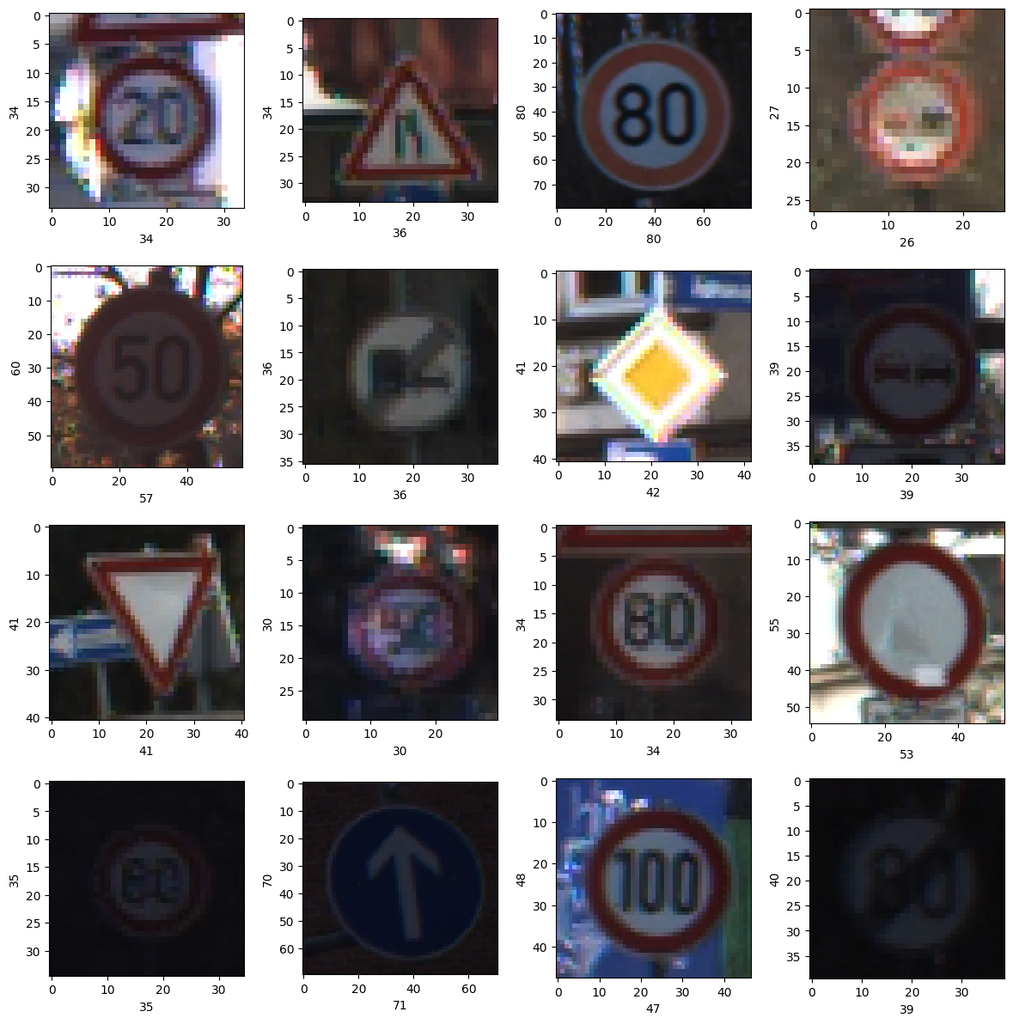

```python
# Plotting 12 images to check dataset
plt.figure(figsize=(12,12))
path = "traffic_sign_dataset/Test"
for i in range(1,17):
    plt.subplot(4,4,i)
    plt.tight_layout()
    rand_img = imread(path +'/'+ random.choice(sorted(os.listdir(path))))
    plt.imshow(rand_img)
    plt.xlabel(rand_img.shape[1], fontsize = 10)#width of image
    plt.ylabel(rand_img.shape[0], fontsize = 10)#height of image
```

### Visualizing Samples from Each Class

It’s also useful to check a few samples from each class to ensure there's diversity in the images for each label. This can help confirm that the data doesn’t have redundant images or any data that could cause biases.

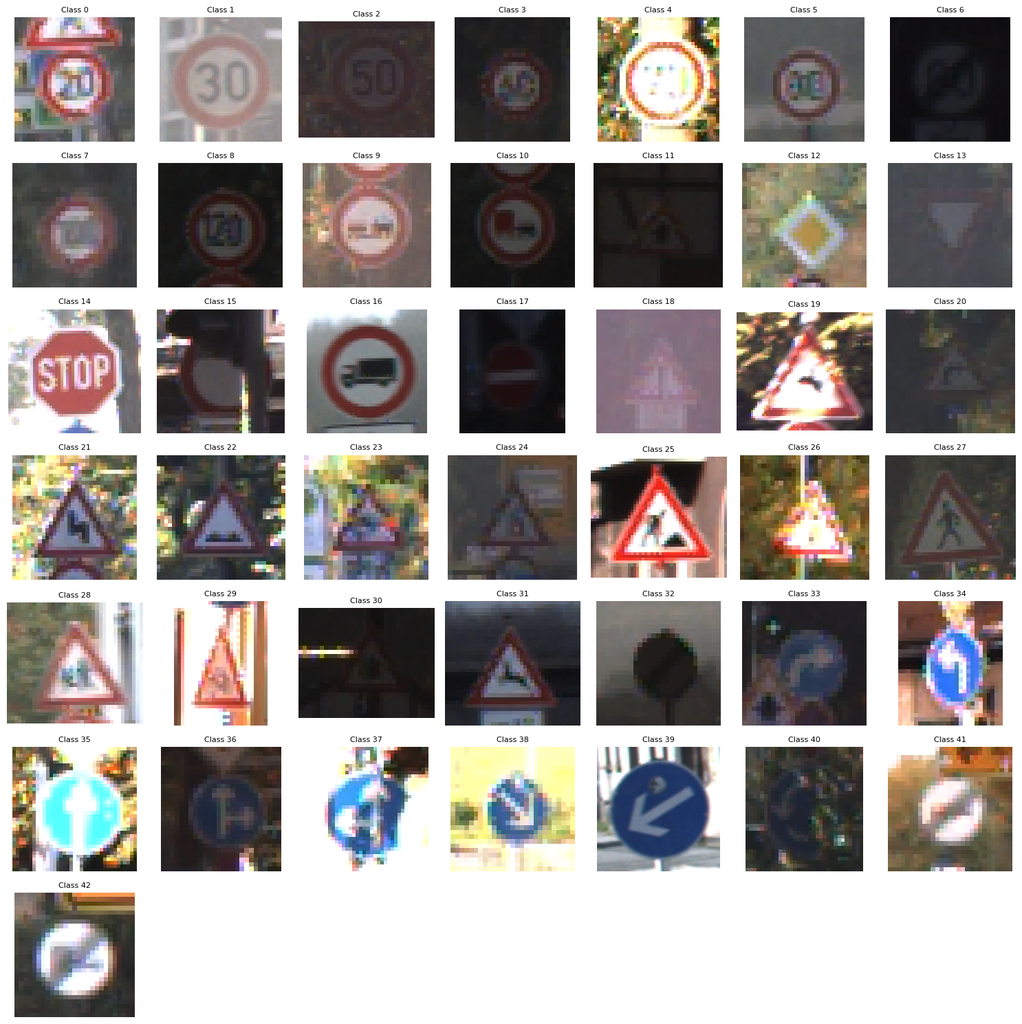

```python
# Visualizing one sample from each class (1 image per class) for training data
plt.figure(figsize=(15, 15))
for i in range(43):
    class_images = sorted(os.listdir(f'traffic_sign_dataset/Train/{i}'))
    img = imread(f'traffic_sign_dataset/Train/{i}/{class_images[0]}')
    plt.subplot(7, 7, i + 1)
    plt.imshow(img)
    plt.axis('off')
    plt.title(f"Class {i}", fontsize=8)

plt.tight_layout()
plt.show()
```

### For further processing we will require the images of same dimension. So, we will start storing the dimension of all the images from training dataset from all 43 classes.

```python
# As size of images are different we have to make them equal so we will take mean of dimenesions
dimension1 = []
dimension2 = []

for i in range(0,43):
    labels = 'traffic_sign_dataset/Train' + '/{0}'.format(i)
    image_path = os.listdir(labels)
    for x in image_path:
        img = imread(labels + '/' + x)
        dimension1.append(img.shape[0])
        dimension2.append(img.shape[1])

print(len(dimension1))
print(len(dimension2))
```

```
39209
39209
```

### Now we will find out the mean value of both the dimensions and analyse them. Here, we can see that (50,50) is the average shape for all the images.

```python
#Printing mean dimension of images
print("Dimension 1 Mean : ",np.mean(dimension1), " Dimension 2 Mean : ",np.mean(dimension2))
```

```
Dimension 1 Mean :  50.328929582493814  Dimension 2 Mean :  50.83587951745773
```

### Now we will reshape the images into (50,50) and also store their label ids.

```python
# Now we will reshape the images to (50,50)
images = []
label_id = []

for i in range(43):
    labels = 'traffic_sign_dataset/Train' + '/{0}'.format(i)
    image_path = os.listdir(labels)
    for x in image_path:
        img = Image.open(labels + '/' + x)
        img = img.resize((50,50))
        img = np.array(img)
        images.append(img)
        label_id.append(i)
```

### Visualizing Class Distribution (Imbalance Check)

Checking the distribution of images across classes helps to identify whether the dataset is balanced or if certain traffic sign classes are overrepresented or underrepresented. A highly imbalanced dataset could require data augmentation or other techniques.

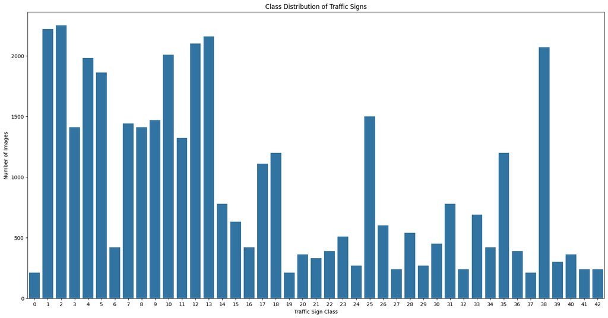

```python
# Assuming `label_id` is the array containing the labels of the images
label_counts = pd.Series(label_id).value_counts()  # Get the distribution of labels

# Plotting the class distribution as a bar chart
plt.figure(figsize=(20, 10))
sns.countplot(x=label_id)  # Count plot for each class label
plt.title('Class Distribution of Traffic Signs')
plt.xlabel('Traffic Sign Class')
plt.ylabel('Number of Images')
plt.show()
```

### Now we will convert all the images into numpy array and normalize them.

```python
#Converting images into numpy array
images = np.array(images)
#The pixel value of each image ranges between 0 and 255
images = images/255
```

### Storing the label ids into numpy array and printing the shape. Here we can observe that their are 39209 label ids.

```python
label_id = np.array(label_id)
label_id.shape
```

```
(39209,)
```

### Checking the shape of the images. Here we can see that their are 39209 images with a shape of (50,50,3.)

```python
images.shape
```

```
(39209, 50, 50, 3)
```

### Now we will observe images per class for checking whether the data is balanced or not. From the result we can say that data is not balanced.

```python
# Visualize the number of classes count
label_counts = pd.DataFrame(label_id).value_counts()
print(label_counts)
```

```
0
2     2250
1     2220
13    2160
12    2100
38    2070
10    2010
4     1980
5     1860
25    1500
9     1470
7     1440
3     1410
8     1410
11    1320
```

[output cut: 30 more lines]

### The next step would be to split the data into training and validation with 80% of training data and 20% of validation data.

```python
#Splitting the data
x_train, x_val, y_train, y_val = train_test_split(images, label_id , test_size = 0.2, random_state = 42)
```

### Converting the classes column into categorical using to_categorical() function.

```python
#keras has a built-in function for one-hot encoding.
y_train_cat = to_categorical(y_train)
y_val_cat = to_categorical(y_val)
```

```python
print("Shape of y_train_cat:", y_train_cat.shape)
print("Shape of y_val_cat:", y_val_cat.shape)
```

```
Shape of y_train_cat: (31367, 43)
Shape of y_val_cat: (7842, 43)
```

```python
# Compute class weights to address class imbalance
class_weights = compute_class_weight(class_weight='balanced', classes=np.unique(y_train), y=y_train)

# Create a dictionary with class labels as keys and their corresponding weights
class_weight_dict = dict(zip(np.unique(y_train), class_weights))
```

### Defining the model architecture. In this we will define all the layers with their input shape kernel size, activation, etc.

```python
# model = Sequential()
# model.add(Conv2D(filters = 64, kernel_size = (3,3), input_shape = x_train.shape[1:], activation = 'relu', padding = 'same', kernel_regularizer=l2(0.001)))
# model.add(MaxPool2D(pool_size=(2,2)))
# model.add(Dropout(0.5))

# model.add(Conv2D(filters = 64, kernel_size = (3,3), activation = 'relu', kernel_regularizer=l2(0.001)))
# model.add(MaxPool2D(pool_size=(2,2)))
# model.add(Dropout(0.5))

# model.add(Flatten())
# model.add(Dense(128, activation = 'relu'))
# model.add(Dropout(0.5))
# model.add(Dense(43, activation = 'softmax'))


############################### Model 2 ##############################################################

model = Sequential()

# First convolutional block
model.add(Conv2D(filters=64, kernel_size=(3, 3), input_shape=x_train.shape[1:], activation='relu', padding='same', kernel_regularizer=l2(0.001)))
model.add(MaxPool2D(pool_size=(2, 2)))
model.add(Dropout(0.3))

# Second convolutional block with more filters
model.add(Conv2D(filters=128, kernel_size=(3, 3), activation='relu', padding='same', kernel_regularizer=l2(0.001)))
model.add(MaxPool2D(pool_size=(2, 2)))
model.add(Dropout(0.3))

# Third convolutional block to capture more features
model.add(Conv2D(filters=256, kernel_size=(3, 3), activation='relu', padding='same', kernel_regularizer=l2(0.001)))
model.add(MaxPool2D(pool_size=(2, 2)))
model.add(Dropout(0.3))

# This layer converts the 3D feature maps from CNN into a 1D vector so that it can be passed to the fully connected layers.
model.add(Flatten())

# Fully connected layer with more neurons
model.add(Dense(256, activation='relu'))
model.add(Dropout(0.3))

# Output layer for classification
model.add(Dense(43, activation='softmax'))

############################################################# Model 3###############################

# model = Sequential()

# # First convolutional layer
# model.add(Conv2D(6, (5, 5), activation='relu', input_shape=(50, 50, 3), padding='same'))  # 6 filters, kernel size 5x5
# model.add(MaxPooling2D(pool_size=(2, 2)))  # MaxPooling after the first convolution

# # Second convolutional layer
# model.add(Conv2D(16, (5, 5), activation='relu'))  # 16 filters, kernel size 5x5
# model.add(MaxPooling2D(pool_size=(2, 2)))  # MaxPooling after the second convolution

# # Flatten the output
# model.add(Flatten())  # Flatten the output for the fully connected layers

# # Fully connected layers
# model.add(Dense(120, activation='relu'))  # Fully connected layer with 120 units
# model.add(Dropout(0.5))  # Dropout for regularization
# model.add(Dense(84, activation='relu'))  # Fully connected layer with 84 units
# model.add(Dropout(0.5))  # Dropout for regularization

# # Output layer for classification (43 classes)
# model.add(Dense(43, activation='softmax'))  # Output layer with 43 units (since we have 43 classes)
```

### Compiling the model using metrics, optimizer and loss as required and printing out the summary of the model.

```python
model.compile(loss = 'categorical_crossentropy', optimizer = 'adam', metrics = ['accuracy'])
model.summary()

# model.compile(loss = 'sparse_categorical_crossentropy', optimizer = 'adam', metrics = ['accuracy'])
# model.summary()
```

```
Model: "sequential_3"
_________________________________________________________________
 Layer (type)                Output Shape              Param #
=================================================================
 conv2d_9 (Conv2D)           (None, 50, 50, 64)        1792

 max_pooling2d_9 (MaxPooling  (None, 25, 25, 64)       0
 2D)

 dropout_12 (Dropout)        (None, 25, 25, 64)        0

 conv2d_10 (Conv2D)          (None, 25, 25, 128)       73856

 max_pooling2d_10 (MaxPoolin  (None, 12, 12, 128)      0
 g2D)

 dropout_13 (Dropout)        (None, 12, 12, 128)       0

 conv2d_11 (Conv2D)          (None, 12, 12, 256)       295168

 max_pooling2d_11 (MaxPoolin  (None, 6, 6, 256)        0
 g2D)

 dropout_14 (Dropout)        (None, 6, 6, 256)         0

 flatten_3 (Flatten)         (None, 9216)              0

 dense_6 (Dense)             (None, 256)               2359552

 dropout_15 (Dropout)        (None, 256)               0

 dense_7 (Dense)             (None, 43)                11051

=================================================================
Total params: 2,741,419
Trainable params: 2,741,419
Non-trainable params: 0
_________________________________________________________________
```

### Early stopping callback setup

```python
# early_stopping = EarlyStopping(monitor='val_accuracy', patience=3, restore_best_weights=True)
```

### Define the checkpoint callback to save the best model

```python
checkpoint = ModelCheckpoint(
    'best_model.h5',  # Path where the best model will be saved
    monitor='val_loss',  # Monitors the validation loss
    save_best_only=True,
    mode='min',  # Saves the model only if the validation loss improves
    verbose=1  # Prints a message when saving the model
)

#checkpoint = ModelCheckpoint('best_model.h5', monitor='val_loss', save_best_only=True, mode='min', verbose=1)
```

### Now we will fit the model and observe how our is getting trained on each epoch.

```python
# model.fit(
#     x_train, y_train_cat,
#     epochs=10,
#     batch_size=128,
#     validation_data=(x_val, y_val),
#     callbacks=[early_stopping, checkpoint],
#     verbose=2
# )

# model.fit(x_train, y_train, epochs = 10, batch_size = 128, validation_data = (x_val, y_val), verbose = 2, callbacks=[checkpoint, early_stopping])

model.fit(
    x_train, y_train_cat,
    epochs=20,
    batch_size=128,
    validation_data=(x_val, y_val_cat),
    verbose=2, callbacks=[checkpoint],
    class_weight=class_weight_dict)

# model.fit(x_train, y_train_cat, epochs=10, batch_size=128, validation_data=(x_val, y_val_cat), verbose=2, callbacks=[checkpoint], class_weight=class_weight_dict)
```

```
Epoch 1: val_loss improved from inf to 1.61288, saving model to best_model.h5
246/246 - 114s - loss: 2.8326 - accuracy: 0.2324 - val_loss: 1.6129 - val_accuracy: 0.5112 - 114s/epoch - 462ms/step

Epoch 2: val_loss improved from 1.61288 to 0.64972, saving model to best_model.h5
246/246 - 109s - loss: 1.0916 - accuracy: 0.6494 - val_loss: 0.6497 - val_accuracy: 0.8610 - 109s/epoch - 441ms/step

Epoch 3: val_loss improved from 0.64972 to 0.40132, saving model to best_model.h5
246/246 - 108s - loss: 0.5971 - accuracy: 0.8165 - val_loss: 0.4013 - val_accuracy: 0.9297 - 108s/epoch - 440ms/step

Epoch 4: val_loss improved from 0.40132 to 0.30196, saving model to best_model.h5
246/246 - 109s - loss: 0.4349 - accuracy: 0.8804 - val_loss: 0.3020 - val_accuracy: 0.9533 - 109s/epoch - 442ms/step

Epoch 5: val_loss improved from 0.30196 to 0.25468, saving model to best_model.h5
246/246 - 108s - loss: 0.3654 - accuracy: 0.9066 - val_loss: 0.2547 - val_accuracy: 0.9732 - 108s/epoch - 441ms/step

Epoch 6: val_loss improved from 0.25468 to 0.20818, saving model to best_model.h5
246/246 - 106s - loss: 0.2969 - accuracy: 0.9295 - val_loss: 0.2082 - val_accuracy: 0.9811 - 106s/epoch - 431ms/step

Epoch 7: val_loss did not improve from 0.20818
246/246 - 106s - loss: 0.2777 - accuracy: 0.9372 - val_loss: 0.2236 - val_accuracy: 0.9782 - 106s/epoch - 431ms/step

Epoch 8: val_loss improved from 0.20818 to 0.18436, saving model to best_model.h5
246/246 - 106s - loss: 0.2525 - accuracy: 0.9467 - val_loss: 0.1844 - val_accuracy: 0.9824 - 106s/epoch - 430ms/step

Epoch 9: val_loss improved from 0.18436 to 0.16072, saving model to best_model.h5
246/246 - 106s - loss: 0.2284 - accuracy: 0.9540 - val_loss: 0.1607 - val_accuracy: 0.9892 - 106s/epoch - 430ms/step

Epoch 10: val_loss did not improve from 0.16072
246/246 - 105s - loss: 0.2070 - accuracy: 0.9595 - val_loss: 0.1629 - val_accuracy: 0.9889 - 105s/epoch - 427ms/step

Epoch 11: val_loss improved from 0.16072 to 0.15166, saving model to best_model.h5
246/246 - 105s - loss: 0.2105 - accuracy: 0.9570 - val_loss: 0.1517 - val_accuracy: 0.9894 - 105s/epoch - 428ms/step

Epoch 12: val_loss improved from 0.15166 to 0.13949, saving model to best_model.h5
246/246 - 107s - loss: 0.1856 - accuracy: 0.9652 - val_loss: 0.1395 - val_accuracy: 0.9929 - 107s/epoch - 435ms/step

Epoch 13: val_loss did not improve from 0.13949
246/246 - 107s - loss: 0.1850 - accuracy: 0.9646 - val_loss: 0.1399 - val_accuracy: 0.9883 - 107s/epoch - 435ms/step

Epoch 14: val_loss improved from 0.13949 to 0.12975, saving model to best_model.h5
246/246 - 105s - loss: 0.1722 - accuracy: 0.9677 - val_loss: 0.1297 - val_accuracy: 0.9943 - 105s/epoch - 428ms/step

Epoch 15: val_loss did not improve from 0.12975
246/246 - 110s - loss: 0.1745 - accuracy: 0.9677 - val_loss: 0.1384 - val_accuracy: 0.9929 - 110s/epoch - 446ms/step

Epoch 16: val_loss improved from 0.12975 to 0.12017, saving model to best_model.h5
246/246 - 112s - loss: 0.1609 - accuracy: 0.9719 - val_loss: 0.1202 - val_accuracy: 0.9950 - 112s/epoch - 456ms/step

Epoch 17: val_loss did not improve from 0.12017
246/246 - 116s - loss: 0.1626 - accuracy: 0.9720 - val_loss: 0.1211 - val_accuracy: 0.9940 - 116s/epoch - 472ms/step

Epoch 18: val_loss did not improve from 0.12017
246/246 - 112s - loss: 0.1549 - accuracy: 0.9725 - val_loss: 0.1226 - val_accuracy: 0.9918 - 112s/epoch - 455ms/step

Epoch 19: val_loss did not improve from 0.12017
246/246 - 112s - loss: 0.1517 - accuracy: 0.9731 - val_loss: 0.1254 - val_accuracy: 0.9920 - 112s/epoch - 455ms/step

Epoch 20: val_loss improved from 0.12017 to 0.11142, saving model to best_model.h5
246/246 - 112s - loss: 0.1466 - accuracy: 0.9754 - val_loss: 0.1114 - val_accuracy: 0.9954 - 112s/epoch - 457ms/step
```

```
<keras.callbacks.History at 0x209906a2a50>
```

### Next we will visualize the accuracy and loss per epoch. For this we will store the model history in the pandas dataframe and plot them.

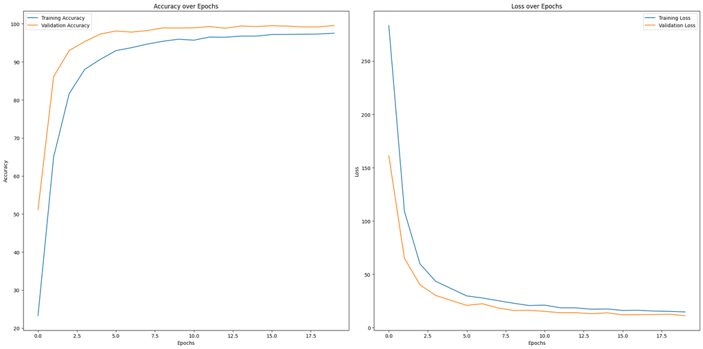

```python
# Plot accuracy for training and validation
plt.figure(figsize=(20, 10))  # Adjust the size of the plot
plt.subplot(1, 2, 1)  # Create a subplot for accuracy
plt.plot(evaluation['accuracy'] * 100, label='Training Accuracy')
plt.plot(evaluation['val_accuracy'] * 100, label='Validation Accuracy')
plt.title('Accuracy over Epochs')
plt.xlabel('Epochs')
plt.ylabel('Accuracy')
plt.legend()

# Plot loss for training and validation
plt.subplot(1, 2, 2)  # Create a subplot for loss
plt.plot(evaluation['loss'] * 100, label='Training Loss')
plt.plot(evaluation['val_loss'] * 100, label='Validation Loss')
plt.title('Loss over Epochs')
plt.xlabel('Epochs')
plt.ylabel('Loss')
plt.legend()

# Show the plots
plt.tight_layout()  # Ensure the plots don't overlap
plt.show()

# evaluation = pd.DataFrame(model.history.history)
# evaluation[['accuracy', 'val_accuracy']].plot()
# evaluation[['loss', 'val_loss']].plot()
```

### List of Traffic Sign Labels

Define the list of labels that correspond to the traffic signs. These labels are used to map the model's numeric predictions to the human-readable class names.

```python
all_labels = [
    'Speed limit (20km/h)', 'Speed limit (30km/h)', 'Speed limit (50km/h)',
    'Speed limit (60km/h)', 'Speed limit (70km/h)', 'Speed limit (80km/h)',
    'End of speed limit (80km/h)', 'Speed limit (100km/h)', 'Speed limit (120km/h)',
    'No passing', 'No passing for vehicles over 3.5 metric tons', 'Right-of-way at the next intersection',
    'Priority road', 'Yield', 'Stop', 'No vehicles', 'Vehicles over 3.5 metric tons prohibited',
    'No entry', 'General caution', 'Dangerous curve to the left', 'Dangerous curve to the right',
    'Double curve', 'Bumpy road', 'Slippery road', 'Road narrows on the right',
    'Road work', 'Traffic signals', 'Pedestrians', 'Children crossing', 'Bicycles crossing',
    'Beware of ice/snow', 'Wild animals crossing', 'End of all speed and passing limits',
    'Turn right ahead', 'Turn left ahead', 'Ahead only', 'Go straight or right',
    'Go straight or left', 'Keep right', 'Keep left', 'Roundabout mandatory',
    'End of no passing', 'End of no passing by vehicles over 3.5 metric tons'
]
```

### Function to Preprocess Test Images

We need to define a function that will load, resize, and scale the images from the test dataset.

```python
def scaling(test_images, test_path):
    images = []
    image_path = test_images

    # Loop through each image and preprocess it
    for x in image_path:
        img = Image.open(test_path + '/' + x)
        img = img.resize((50,50))  # Resizing images to 50x50
        img = np.array(img)
        images.append(img)

    # Convert images to numpy array and scale pixel values
    images = np.array(images)
    images = images / 255  # Normalize pixel values between 0 and 1

    return images
```

### Load and Preprocess Test Images

Now, we will preprocess the images by calling the scaling function, which resizes and normalizes the images to make them ready for prediction.

```python
# Path to the test dataset
test_path = 'traffic_sign_dataset/Test'

# Load and scale the test images
test_images = scaling(sorted(os.listdir(test_path)), test_path)
```

### Make Predictions Using the Trained Model

Now that the test images are preprocessed, we can use the trained model to predict the traffic signs.

```python
# Make predictions on the test images
y_pred = np.argmax(model.predict(test_images), axis=-1)
```

### Map Predictions to Class Names

The model outputs numerical predictions (class indices), so we need to map these predictions to the actual class labels (traffic signs).

```python
# Map the predicted numeric labels to class names
predicted_classes = [all_labels[label] for label in y_pred]
```

### Visualize the Predictions

Let's now visualize the first 12 test images and display the predicted traffic sign labels.

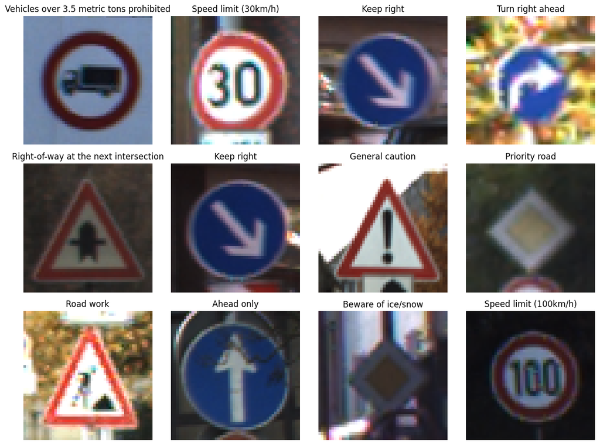

```python
plt.figure(figsize=(12, 12))
for i in range(12):  # Visualize 12 test images with predictions
    plt.subplot(4, 4, i + 1)
    plt.imshow(test_images[i])
    plt.title(predicted_classes[i], fontsize=12)
    plt.axis('off')
plt.tight_layout()
plt.show()
```

### Classification Report

```python
# Assuming 'meta_data.csv' is the file containing your metadata.
meta_data = pd.read_csv('./traffic_sign_dataset/Test.csv')

# Extract the paths and true labels
image_paths = meta_data['Path'].values
true_labels = meta_data['ClassId'].values  # These are the true labels (ground truth)

# Assuming 'meta_data' contains the ground truth information
y_true = meta_data['ClassId'].values  # This will be the true label for each image

# Now you can compare y_true with y_pred (predicted labels from the model)
y_pred = np.argmax(model.predict(test_images), axis=-1)

# Map the predicted numeric labels to class names (for visualization)
predicted_classes = [all_labels[label] for label in y_pred]

# Generate and print classification report
from sklearn.metrics import classification_report
print("Classification Report:")
print(classification_report(y_true, y_pred, target_names=all_labels))
```

```
Classification Report:
                                                    precision    recall  f1-score   support

                              Speed limit (20km/h)       0.88      1.00      0.94        60
                              Speed limit (30km/h)       0.98      0.97      0.97       720
                              Speed limit (50km/h)       0.96      0.97      0.97       750
                              Speed limit (60km/h)       0.93      0.93      0.93       450
                              Speed limit (70km/h)       0.98      0.97      0.97       660
                              Speed limit (80km/h)       0.89      0.94      0.91       630
                       End of speed limit (80km/h)       0.97      0.74      0.84       150
                             Speed limit (100km/h)       0.98      0.89      0.93       450
                             Speed limit (120km/h)       0.92      0.96      0.94       450
                                        No passing       0.98      0.98      0.98       480
      No passing for vehicles over 3.5 metric tons       0.99      0.98      0.98       660
             Right-of-way at the next intersection       0.92      0.99      0.96       420
                                     Priority road       0.98      0.96      0.97       690
                                             Yield       0.99      1.00      0.99       720
                                              Stop       0.97      1.00      0.99       270
                                       No vehicles       0.98      1.00      0.99       210
          Vehicles over 3.5 metric tons prohibited       1.00      1.00      1.00       150
                                          No entry       1.00      0.97      0.99       360
                                   General caution       0.99      0.85      0.92       390
                       Dangerous curve to the left       0.92      0.98      0.95        60
                      Dangerous curve to the right       0.76      1.00      0.86        90
                                      Double curve       0.58      0.59      0.58        90
                                        Bumpy road       0.98      0.97      0.97       120
                                     Slippery road       0.87      0.95      0.90       150
                         Road narrows on the right       1.00      0.84      0.92        90
                                         Road work       0.97      0.94      0.95       480
                                   Traffic signals       0.83      0.94      0.88       180
                                       Pedestrians       0.71      0.57      0.63        60
                                 Children crossing       0.97      0.93      0.95       150
                                 Bicycles crossing       0.80      0.99      0.89        90
                                Beware of ice/snow       0.89      0.60      0.72       150
                             Wild animals crossing       0.84      0.97      0.90       270
               End of all speed and passing limits       0.69      1.00      0.82        60
                                  Turn right ahead       0.97      0.99      0.98       210
                                   Turn left ahead       0.99      0.99      0.99       120
                                        Ahead only       0.98      0.98      0.98       390
                              Go straight or right       0.98      0.97      0.97       120
                               Go straight or left       1.00      0.98      0.99        60
                                        Keep right       0.99      0.99      0.99       690
                                         Keep left       0.97      0.94      0.96        90
                              Roundabout mandatory       0.98      0.92      0.95        90
                                 End of no passing       1.00      0.87      0.93        60
End of no passing by vehicles over 3.5 metric tons       0.86      1.00      0.92        90

                                          accuracy                           0.95     12630
                                         macro avg       0.93      0.93      0.92     12630
                                      weighted avg       0.95      0.95      0.95     12630
```

### Precision-Recall Curve

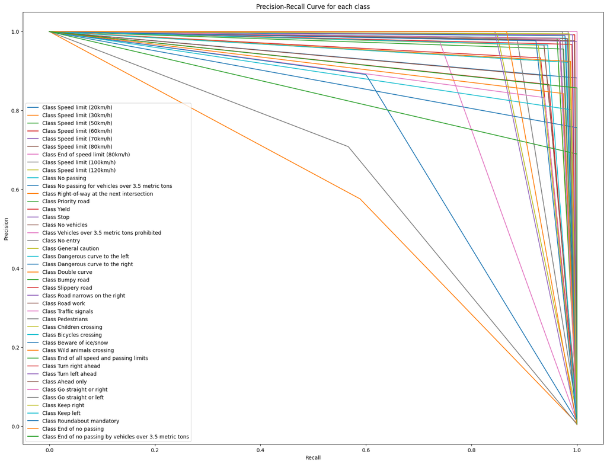

```python
precision = {}
recall = {}
for i in range(len(all_labels)):
    precision[i], recall[i], _ = precision_recall_curve(y_true == i, y_pred == i)

# Plot Precision-Recall curve for each class
plt.figure(figsize=(20, 15))
for i in range(len(all_labels)):
    plt.plot(recall[i], precision[i], label=f'Class {all_labels[i]}')

plt.xlabel('Recall')
plt.ylabel('Precision')
plt.title('Precision-Recall Curve for each class')
plt.legend(loc='lower left')
plt.show()
```

### ROC Curve and AUC Score

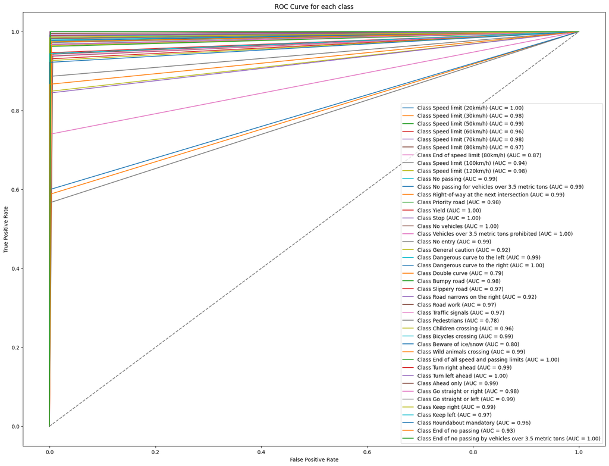

```python
# Binarize the labels for ROC curve (multi-class)
y_true_bin = label_binarize(y_true, classes=range(len(all_labels)))
y_pred_bin = label_binarize(y_pred, classes=range(len(all_labels)))

# Compute ROC curve and AUC for each class
fpr, tpr, roc_auc = {}, {}, {}
for i in range(len(all_labels)):
    fpr[i], tpr[i], _ = roc_curve(y_true_bin[:, i], y_pred_bin[:, i])
    roc_auc[i] = auc(fpr[i], tpr[i])

# Plot ROC curve
plt.figure(figsize=(20, 15))
for i in range(len(all_labels)):
    plt.plot(fpr[i], tpr[i], label=f'Class {all_labels[i]} (AUC = {roc_auc[i]:.2f})')

# Plot random chance line (diagonal)
plt.plot([0, 1], [0, 1], color='gray', linestyle='--')

plt.xlabel('False Positive Rate')
plt.ylabel('True Positive Rate')
plt.title('ROC Curve for each class')
plt.legend(loc='lower right')
plt.show()
```

### Confusion Matrix

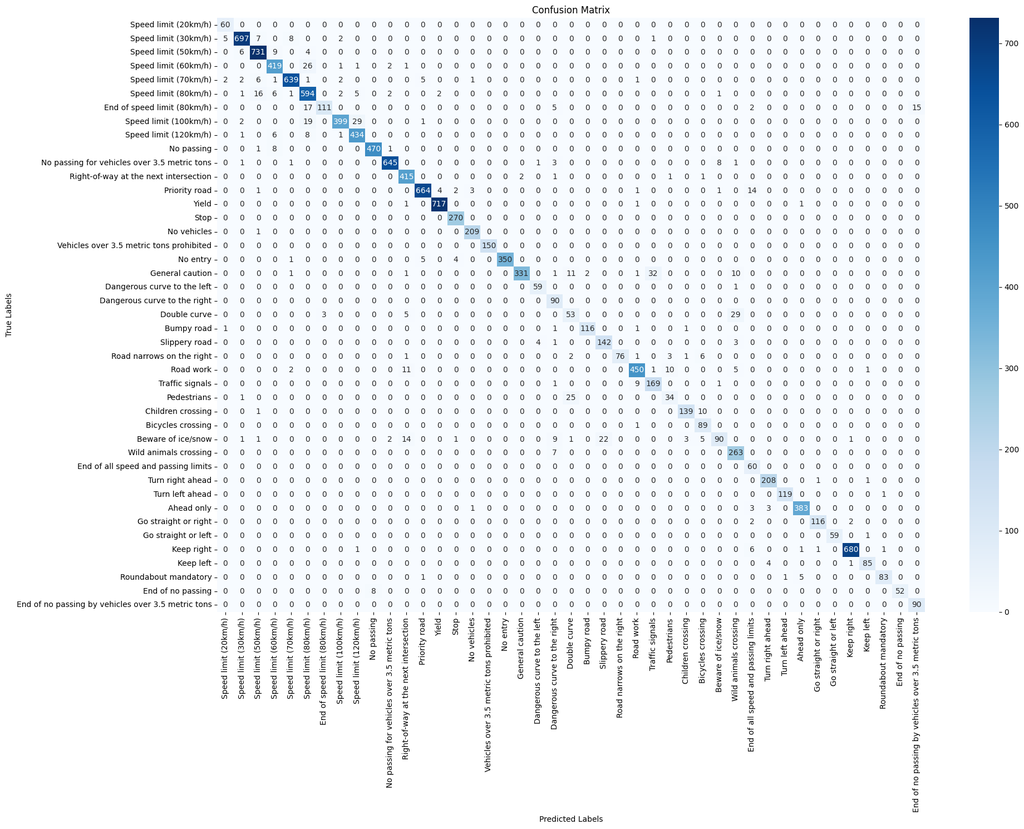

```python
from sklearn.metrics import confusion_matrix

# Compute confusion matrix
cm = confusion_matrix(y_true, y_pred)

# Plot confusion matrix
plt.figure(figsize=(20, 15))
sns.heatmap(cm, annot=True, fmt='d', cmap='Blues', xticklabels=all_labels, yticklabels=all_labels)
plt.xlabel('Predicted Labels')
plt.ylabel('True Labels')
plt.title('Confusion Matrix')
plt.xticks(rotation=90)
plt.tight_layout()
plt.show()
```

# Scope:

This model can be used in self driving cars which will enable them to automatically recognize traffic signs similarly the driver alert system inside cars will help and protect drivers by understanding the traffic signs around them.